# Assignment 2

Cristian Alberto Barrios Espinosa

14-10-2019

This is Assignment 2 for Scientific Programming course of Systems Biology master at Maastricht University The goal of this assignment is to create a regression model to predict the boiling point of different kinds of alkanes based on other properties. The first step will be using different libraries to build this model. This will be useful to make a query about the alkanes with “wikidataQueryServiceR” extract their features with rcdk, perform the regression model with “pls” and plot the results with “gplots”. The version of R will be R version 3.5.2 (2018-12-20). The Wikidata Query Service R provides the opportunity to make queries via SPARQL in an R environment. Package “rcdk” allows usage of “CDK” for chemoinformatics which is a Java framework. Between many possibilities this tool facilitates the obtention of load molecules, molecular descriptors, 2d view structures, etc. “PLS” allows multivariable regression methods, Partial Least Squares Regression, Principal Component Regression, and Canonical Powered Partial Least Squares.tictoc is a package to count the time of running code in different sessions that demmand longer time. EnvStats has the rosner test useful to find outliers.

The next step is to make a query to obtain all the alkanes from wikidata with their boiling points and their smiles in order to be able to extract the features using rcdk package later. The important data extracted from wikidata will be names, boiling points, units of boiling points and smiles. Additional commands are made in order to obtain the units and to show the results in English. It is seen in the data that not all the units are the same. Only the important columns are considered and the number of alkanes is obtained for future calculations. Some of them are in Celsius, Fahrenheit or Kelvin. In the output of this chunk of code is possible to see the first six elements of the results

```r
tic("time for the query")
sparql_query <- 'SELECT ?comp ?compLabel ?bp ?bpUnit ?bpUnitLabel ?smiles WHERE {
  ?comp wdt:P31/wdt:P279* wd:Q41581 ;
p:P2102 [
ps:P2102 ?bp ;
psv:P2102/wikibase:quantityUnit  ?bpUnit
];
 wdt:P233 ?smiles.
SERVICE wikibase:label { bd:serviceParam wikibase:language "[AUTO_LANGUAGE],en". }
}'
toc()
```

```
## time for the query: 0 sec elapsed
```

```r
results_query <- query_wikidata(sparql_query)
```

```
## 142 rows were returned by WDQS
```

```r
list_alkanes  <-results_query[,c(2,3,5,6)]
nalkanes<-nrow(list_alkanes)
colnames(list_alkanes)  <- c('Name','Boiling_point','Unit','Smile')
print(head(list_alkanes[,-4]))#First six alkanes and boiling points
```

```
##                Name Boiling_point   Unit
## 1   Henheptacontane        928.15 kelvin
## 2   Henpentacontane        857.15 kelvin
## 3    Henoctacontane        948.55 kelvin
## 4    Hennonacontane        973.15 kelvin
## 5    Henhexacontane        897.05 kelvin
## 6 Pentaheptacontane        939.15 kelvin
```

```r
print(head(list_alkanes[,4]))#First six alkanes and smiles
```

```
## [1] "CCCCCCCCCCCCCCCCCCCCCCCCCCCCCCCCCCCCCCCCCCCCCCCCCCCCCCCCCCCCCCCCCCCCCCC"
## [2] "CCCCCCCCCCCCCCCCCCCCCCCCCCCCCCCCCCCCCCCCCCCCCCCCCCC"
## [3] "CCCCCCCCCCCCCCCCCCCCCCCCCCCCCCCCCCCCCCCCCCCCCCCCCCCCCCCCCCCCCCCCCCCCCCCCCCCCCCCCC"
## [4] "CCCCCCCCCCCCCCCCCCCCCCCCCCCCCCCCCCCCCCCCCCCCCCCCCCCCCCCCCCCCCCCCCCCCCCCCCCCCCCCCCCCCCCCCCCC"
## [5] "CCCCCCCCCCCCCCCCCCCCCCCCCCCCCCCCCCCCCCCCCCCCCCCCCCCCCCCCCCCCC"
## [6] "CCCCCCCCCCCCCCCCCCCCCCCCCCCCCCCCCCCCCCCCCCCCCCCCCCCCCCCCCCCCCCCCCCCCCCCCCCC"
```

To make the units homogenous, the alkanes in which boiling points were found in Celsius or Fahrenheit will be changed to Kelvin. Otherwise the results of the model might be invalid. All the boiling points of alkanes in Celsius will be put in the vector called Celsius, after that the units will be changed into Kelvin in the list of alkanes. The same process will be repeated with alkanes in Fahrenheit.

```r
#Change of Celsius - Kelvin
#Put all the boiling points in a vector called celsius
celsius<-list_alkanes[which(list_alkanes$Unit=='degree Celsius'),2]

#Apply the formula to change to Kelvin in the vector celsius and replace the new values in the original list of alkanes
list_alkanes[which(list_alkanes$Unit=='degree Celsius'),2]<- celsius+273.15

#Change of Fahrenheit - Kelvin (Same as in celisus but with the corresponding formula)
fahrenh<-list_alkanes[which(list_alkanes$Unit=='degree Fahrenheit'),2]
list_alkanes[which(list_alkanes$Unit=='degree Fahrenheit'),2]<-(fahrenh - 32) * 5/9 + 273.15

#Change all the units to kelvin now the values have been changed
list_alkanes$Unit <-'Kelvin'

#Exploration of the boiling points dataset, basic statistical analysis
print(summary(list_alkanes))
```

```
##      Name           Boiling_point       Unit              Smile
##  Length:142         Min.   :111.4   Length:142         Length:142
##  Class :character   1st Qu.:386.8   Class :character   Class :character
##  Mode  :character   Median :636.2   Mode  :character   Mode  :character
##                     Mean   :645.6
##                     3rd Qu.:908.9
##                     Max.   :994.1
```

The first part of this algorithm is a function to define the RMSEP for 3 components. The inputs are the boiling points, the parsed smiles, and descriptors training and test vectors that contain indexes to select the respective variables and will be chosen randomly.

The reason why 3 components were selected was that it was observed for multiple selections of descriptors in the initial exploration of data most of the times good approximations are obtained after taking three components or four components in most of the cases. As 3 components are the minimum to save computational time and still be accurate, it was the number of components selected to feed the algorithm.

Before starting to define the function and the algorithm some parameters must be defined and some varibles must be initialized.

```r
#Parsing smiles
parsed_smiles_alkanes<-parse.smiles(list_alkanes$Smile)

#This variable with boiling points will be input of the function RMSEP_3comp_function as well as the dependend variable of the model.
boiling_points<-as.data.frame(list_alkanes$Boiling_point)

#First ideal value for RMSEP and ideal vector are initialized in these two variables.
ideal_RMSEP<-1000
ideal_vector<-c(1:10)

#This variable is a vector with elements which are numbers between 1 and 50 (the amount of descriptors) and store the indexes of the descriptors that will be used in the model.
descriptor_vector<-c(1:10)
```

A funtion will be defined to calculated the RMSEP for 3 components that takes as input the vector with indexes of the descriptors, the smiles, and the indexes of the traning sets and test sets.

```r
RMSEP_3comp_function <- function (descriptor_vector,parsed_smiles,boiling_points,train_vector,test_vector)
{
  #Descriptor names is a variable that stores the names of the descriptors use in the model and uses the vector with indexes and the function get.desc.names from rcdk package to get them.
  descriptor_names   <-get.desc.names()[(descriptor_vector)]


  #The following 4 lines deal with the data for the independent data for the regression model that comes from the chosen descriptors. There is a replacement of the NA by zeros. The array must be transformed into a matrix in order to make the replacement possible.
  regression_data_alkanes <- eval.desc(parsed_smiles,descriptor_names)
  regression_data_alkanes <- as.matrix(regression_data_alkanes)
  regression_data_alkanes[which(is.na(regression_data_alkanes))]<- 0
  regression_data_alkanes <- as.data.frame(regression_data_alkanes)

  #The boiling points (dependend variable of the model) are included in the data for the regresion model and the column is named 'bp'.
   regression_data_alkanes <- cbind(regression_data_alkanes,boiling_points)
   colnames(regression_data_alkanes)[ncol(regression_data_alkanes)] <-'bp'

  #The data for the regresion model are divided in two sets (trainning and test) the selection is guided by the indexes used as input for the funtion.

  #Remember that the indexes of the training and test sets are complementary, united form the whole set of alkanes.
  train_set <-regression_data_alkanes[train_vector,]
  test_set<- regression_data_alkanes[test_vector,]

  # Partial least squares Regression model with leave one out cross validation for the trainning set.
  model_alkanes <- plsr(bp ~ ., ncomp = 3, data = train_set, validation = "LOO")

 #The following three lines of code are made to extract the RMSEP for 3 components in the test set
   RMSEP_test<-RMSEP( model_alkanes, newdata = test_set)
   RMSEP_test_values<-RMSEP_test$val
   RMSEP_test_3comp<-RMSEP_test_values[1,1,4]

   #The output of the function is the RMSEP for the three components
  return (RMSEP_test_3comp)
}
```

```r
#Start counting running time for the algorithm
tic("time running the algorithm")

#counter 1 is a variable to run over the 50 iterations where 50 possible combinations of randomly selected descriptors will be tested an the first assigned value is zero.
counter1=0

while (counter1<=5)
{
  # Increment of the counter 1 to avoid infinite while loop
  counter1=counter1+1

  #size_vector will be a number between 3 and 50 and represents the amount of descriptors that will be used in the model during each iteration.
  size_vector=sample(c(3:50), size=1)

  #Making a random selection of descriptors to find the best prediction chosing as many descriptor as the number in size_vector
  descriptor_vector <- sample (c(1:50), size=size_vector)

  #Second counter is introduced that will go from 1 to 4. In each iteration of counter 2, a new training and test data sets will be randomly generated from the original data. The training set will always be the 80% of the alkanes found in the query and the test set will be the remaining 20%.
  counter2<-1

  #The average of RMSEP for all the iterations of the counter 2 will be calculated. For these reason is initialize as zero.
    RMSEP_test_3comp<-0

    while (counter2<4)
  {
    #Uncomment next line to see the progress of the algorithm,
    #print(c(counter1,counter2))

    #Select the train vector of indexes as a random 80% elements of the list of number of alkanes
    train_vector<-sample(c(1:nalkanes),floor(nalkanes*0.80))

    #Select the test vector of indexes as the remaining 20% elements of the list of number of alkanes
    test_vector<-setdiff(c(1:nalkanes),train_vector)

    #Use the previously defined function to calculate the RMSEP for each descriptor vector and each training/test data sets for three components and add this value to the sum of RMSEP found in previous iterations.
    RMSEP_test_3comp<-RMSEP_test_3comp+RMSEP_3comp_function(descriptor_vector,parsed_smiles_alkanes,boiling_points,train_vector,test_vector)

    #counter 2 is increased to avoid infinite loops
    counter2<-counter2+1
    }

  #At the end of the inner while a total sum of RMSEP will be obtained. It will be divided by 4 to get the average
  RMSEP_test_3comp<-RMSEP_test_3comp/4

  #"if operator" will used to replace the ideal RMSEP and the ideal vector for the current RMSEP average and descriptor vector in case that the current RMSEP is smaller than the ideal RMSEP.
  if (RMSEP_test_3comp<=ideal_RMSEP)
  {
    ideal_RMSEP  <- RMSEP_test_3comp
    ideal_vector <- descriptor_vector

    #Print the ideal vector and the RMSEP that it produces when a better result    is achieved
    print(RMSEP_test_3comp)
    print(descriptor_vector)
  }

}
```

```
## [1] 29.93342
##  [1] 42 12 35 38 15 28 13  9 10  6 50 26 45 36 16 32 34  1  7 25 46 37 19
## [24] 41 43 22 31  3 18 39 14 40 33 21 29 44 48 17 27 49 20  8  2 24
## [1] 27.55717
##  [1]  2  5 34 31  4 20 50 32  6 49 14  7  3 13 17  1
## [1] 13.57477
##  [1] 36 22 18 12 37 20 41  1 16 50 31 49 39 46 19 15  5 30 28 21 17 47  8
## [24] 44  7  4 32 40 29 14 13 35 45 26  6  9 27
```

```r
#Print output of the algorithm
print(ideal_vector)
```

```
##  [1] 36 22 18 12 37 20 41  1 16 50 31 49 39 46 19 15  5 30 28 21 17 47  8
## [24] 44  7  4 32 40 29 14 13 35 45 26  6  9 27
```

```r
print(ideal_RMSEP)
```

```
## [1] 13.57477
```

```r
toc()
```

```
## time running the algorithm: 1042.08 sec elapsed
```

After finding the best combination of descriptors according to the algorithm to get the smallest RMSEP similar process will be repeated like inside the algorithm but including corresponding analysis and plots. Please note that the ideal combination of descriptors indexes will be found in the variable ideal_vector. However as it is a random process and the algorithm can take several hours to run, for the rest of the code the ideal vector will be considered as c(28, 31, 9, 2, 14, 44, 48, 21, 11, 4). Nonetheless, if the code is run again, the results will be likely different but sill with small RMSEP.

```r
#Select a list of descriptors to build the model from rcdk
descriptor_names   <-get.desc.names()[c(28, 31,  9,  2, 14, 44, 48, 21, 11,  4)]

# #Print descriptor names
print(descriptor_names)
```

```
##  [1] "org.openscience.cdk.qsar.descriptors.molecular.GravitationalIndexDescriptor"
##  [2] "org.openscience.cdk.qsar.descriptors.molecular.EccentricConnectivityIndexDescriptor"
##  [3] "org.openscience.cdk.qsar.descriptors.molecular.VAdjMaDescriptor"
##  [4] "org.openscience.cdk.qsar.descriptors.molecular.FractionalPSADescriptor"
##  [5] "org.openscience.cdk.qsar.descriptors.molecular.PetitjeanShapeIndexDescriptor"
##  [6] "org.openscience.cdk.qsar.descriptors.molecular.AutocorrelationDescriptorCharge"
##  [7] "org.openscience.cdk.qsar.descriptors.molecular.APolDescriptor"
##  [8] "org.openscience.cdk.qsar.descriptors.molecular.LargestPiSystemDescriptor"
##  [9] "org.openscience.cdk.qsar.descriptors.molecular.TPSADescriptor"
## [10] "org.openscience.cdk.qsar.descriptors.molecular.XLogPDescriptor"
```

```r
#Find the descriptors values for each alkane and putting them in a variable called "regression_data_alkanes"
regression_data_alkanes <- eval.desc(parsed_smiles_alkanes,descriptor_names)

#Converting the data in matrix to remove the NA
regression_data_alkanes <- as.matrix(regression_data_alkanes)

#Change the NA for zeros in order to avoid errors in the model
regression_data_alkanes[which(is.na(regression_data_alkanes))]<- 0

#Transform the descriptors vector in a data fram to be an acceptable input for the model.
regression_data_alkanes <- as.data.frame(regression_data_alkanes)

#Binding the last column with the boiling points to complete the regression data with the values that will be predicted
regression_data_alkanes <- cbind(regression_data_alkanes,list_alkanes$Boiling_point)

#Naming the last column of boiling points as "bp"
colnames(regression_data_alkanes)[ncol(regression_data_alkanes)] <-'bp'
```

Now that the data frame with all the dependent and independent variables is ready, the regression model can be made based on this data. First, a train and data set should be selected. The kind of model used is Partial least squares regression. It finds a linear regression model by projecting the independent and dependend variables into an additional space. It is particulary suitable for cases like this where the amount of observable variables is big.

```r
#Defining train set as the first 114 alkanes of the list
train_set <-regression_data_alkanes[1:114,]
row.names(train_set)<-c(1:114)

#Reporting size of train set
print(length(train_set))
```

```
## [1] 24
```

```r
#Defining test set as the last 29 alkanes of the list
test_set<- regression_data_alkanes[115:nalkanes,]
row.names(test_set)<-c(1:nrow(test_set))

#Reporting size of test set
print(length(test_set))
```

```
## [1] 24
```

```r
#Defining the model using pls package using the training set as input the validation is done with the technic Leave-one-Out.
model_alkanes <- plsr(bp ~ ., ncomp = 4, data = train_set, validation = "LOO")
```

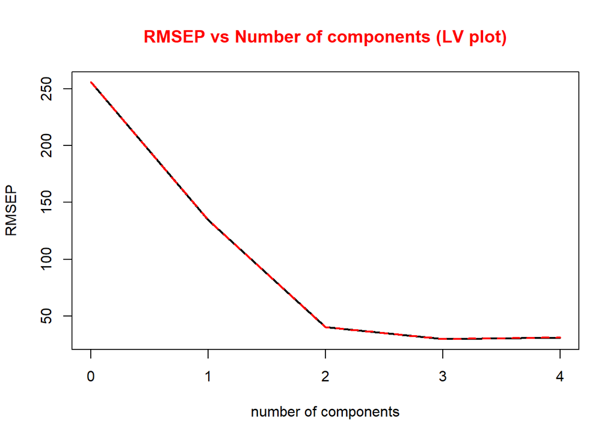

```r
#Plot of RMSEP for each one of the number of components, it is possible to see how with 3 components the RMSEP reduced significatly.
plot(RMSEP(model_alkanes),main="RMSEP vs Number of components (LV plot)",col.main="red",lwd=2)
```

```r
#Print the RMSEP
RMSEP(model_alkanes)
```

```
##        (Intercept)  1 comps  2 comps  3 comps  4 comps
## CV             256    134.5    40.05    29.63    31.04
## adjCV          256    134.5    40.05    29.62    31.02
```

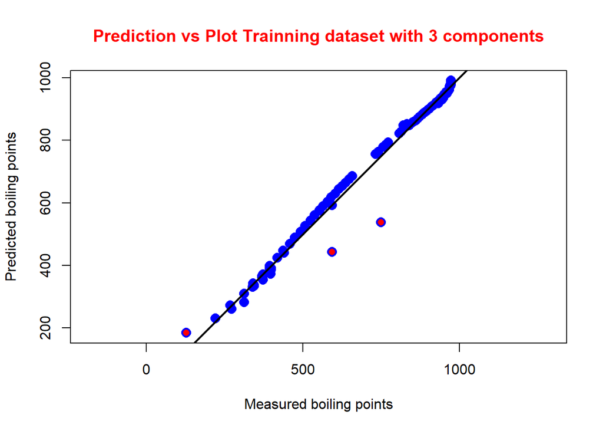

```r
#Extracting two vectors with predicted and measured values from the model and wikidata query to make the plot.
predicted_values <- as.matrix(predict(model_alkanes, ncomp = 3, newdata = train_set)[,1,1])
measured_values <- as.matrix(boiling_points)[1:114]


#Calculate Outliers: First calculate the error for each value as the distance from the  diagonal.
error_vector<-sqrt((measured_values-((measured_values+predicted_values)/2))^2+(predicted_values-((measured_values+predicted_values)/2))^2)

#Apply RosnerTest to find outliers
outliers<-rosnerTest(error_vector)


#Extract outliers index from the output
outliers<-outliers$all.stats$Obs.Num

#Plot of predicted values vs measured values for the trainning set
plot(predicted_values,measured_values,xlab="Measured boiling points",ylab="Predicted boiling points", main="Prediction vs Plot Trainning dataset with 3 components",lwd=1,asp=1,pch=16,col="blue", cex=1.5,cex.main=1.2,col.main="red")


#Plot outliers in red over the data
points(predicted_values[outliers],measured_values[outliers],col="red",pch=16)

#Add the diagonal line.
abline(a=0,b=1,lwd=2)
```

```r
#Display list of outliers
print("The outliers are")
```

```
## [1] "The outliers are"
```

```r
print(list_alkanes[outliers,1])
```

```
## [1] "hexatriacontane" "phytane"         "ethane"
```

In the previous plot in blue, it is displayed all the dataset, the outliers are highlighted in red. Now with the model built is time to apply the model in the test set where first the RMSEP will be found. Then a scatter plot comparing predicted and measured values will be displayed.

```r
#Applying function RMSEP from pls package to find the RMSEP for all the components in the model.
RMSEP_test<-RMSEP(model_alkanes, newdata = test_set)

#Make a vector only with the values of the RMSEP for each component
RMSEP_values<-RMSEP_test$val

#Find the value of RMSEP with 3 components, it is the 4th element because the first is the intercept.
RMSEP_3comp<-RMSEP_values[1,1,4]

print('RMSEP for 3 components in the test set is:')
```

```
## [1] "RMSEP for 3 components in the test set is:"
```

```r
print(RMSEP_3comp)
```

```
## [1] 25.22052
```

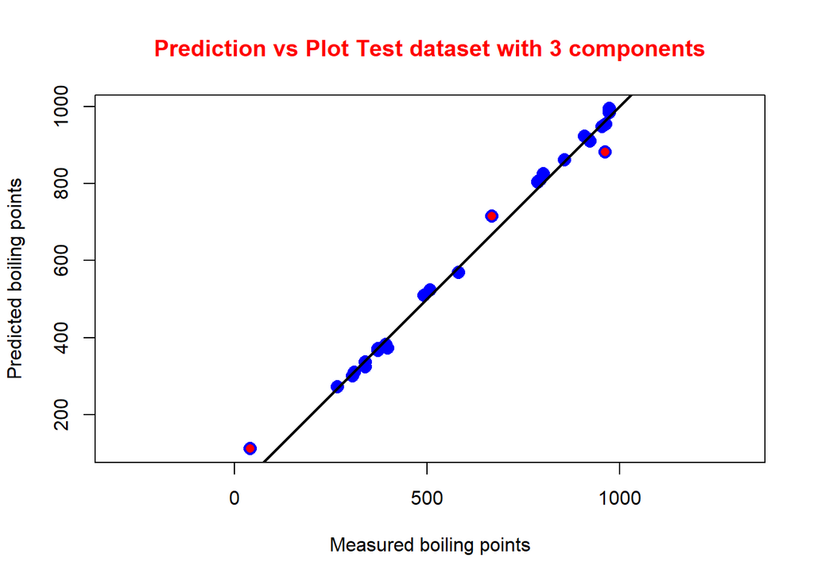

```r
#predicted values using the test_set in the model obtained from the training set. Predict function takes the better fit of the model for the test dataset.The output of "predict"" is transformed into a matrix and the elements of the first dimension are selected to be displayed in a plot. Transformation from data.frame to matrix is necessary to isolated the elements of the first dimension.
predicted_values <- as.matrix(predict(model_alkanes, ncomp = 3, newdata = test_set)[,1,1])

#Measured boiling points extracted previously from wikidata for the alkanes in the test set.
measured_values <- as.matrix(boiling_points)[115:142]


#Calculate Outliers: First calculate the error for each value as the distance from the  diagonal.
error_vector<-sqrt((measured_values-((measured_values+predicted_values)/2))^2+(predicted_values-((measured_values+predicted_values)/2))^2)

#Apply RosnerTest to find outliers
outliers<-rosnerTest(error_vector)


#Extract outliers index from the output
outliers<-outliers$all.stats$Obs.Num

#Plot of predicted values vs measured values for the test set
plot(predicted_values,measured_values,xlab="Measured boiling points",ylab="Predicted boiling points", main="Prediction vs Plot Test dataset with 3 components",lwd=1,asp=1,pch=16,col="blue", cex=1.5,cex.main=1.2,col.main="red")


#Plot outliers in red over the data
points(predicted_values[outliers],measured_values[outliers],col="red",pch=16)

#Add the diagonal line.
abline(a=0,b=1,lwd=2)
```

```r
#Display list of outliers
print("The outliers are")
```

```
## [1] "The outliers are"
```

```r
print(list_alkanes[outliers+114,1])
```

```
## [1] "Dooctacontane" "methane"       "heptacosane"
```

References